# Analiza wyników PISA w UK

Paulina Przybyłek & Przemysław Chojecki

23 października 2019

## Wielka Brytania na tle innych państw

Spojrzenie na Wielką Brytanię poprzez porównanie z państawami Europy [wykres 1], a następnie z państawami uznanymi za takie, które mają najlepszy system edukacji [wykres 2] ( do analizy wykorzystano 18 najlepszych państw wedle rankingu).

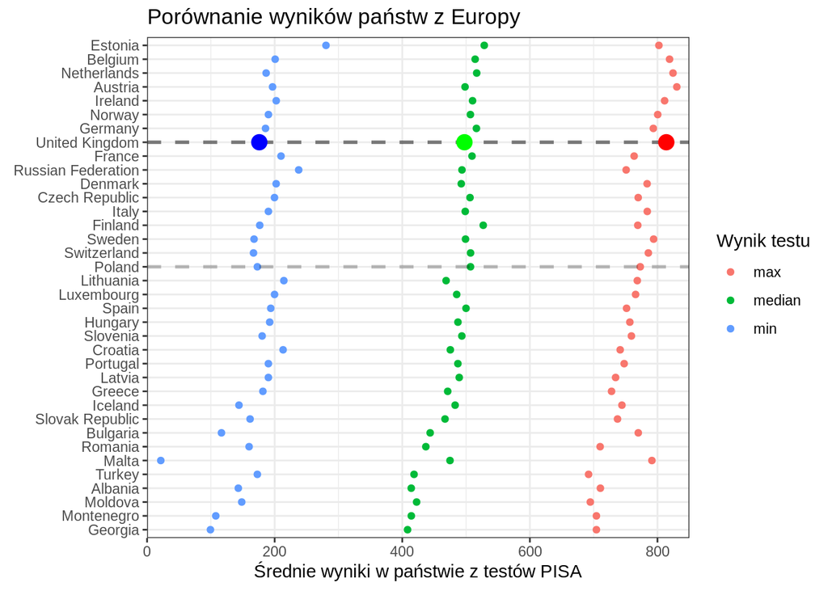

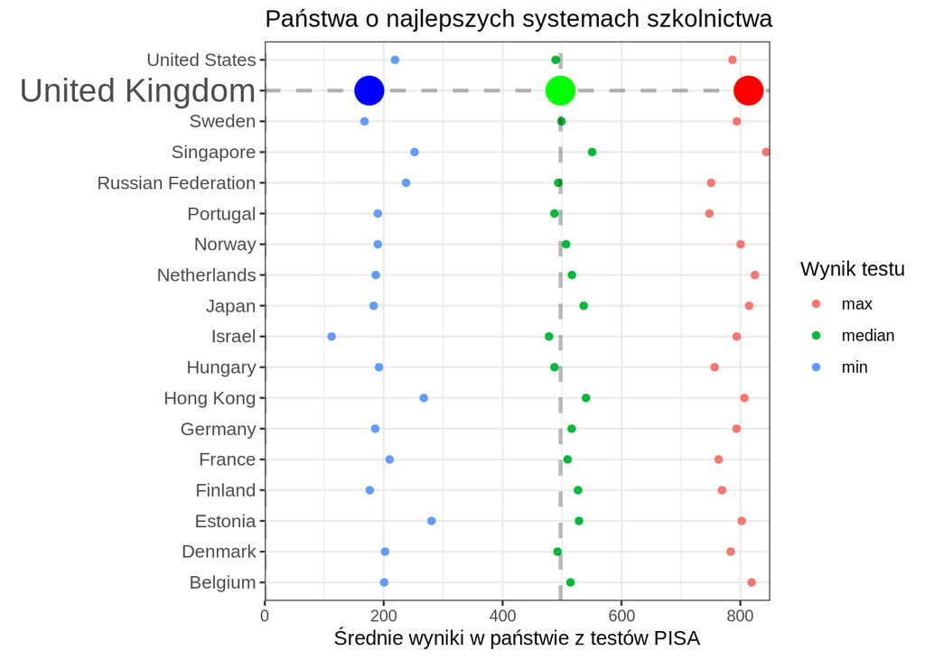

## Wielka Brytania jako państwo z podziałem na płeć uczniów

W Wielkiej Brytanii występują szkoły męskie, żeńskie i mieszane, które dodatkowo mają kolejny podział na typ (prywatne/publiczne, akademienie/niezależne/itp., itd.). Skupimy się najpierw na wynikach uczniów w tych szkołach.

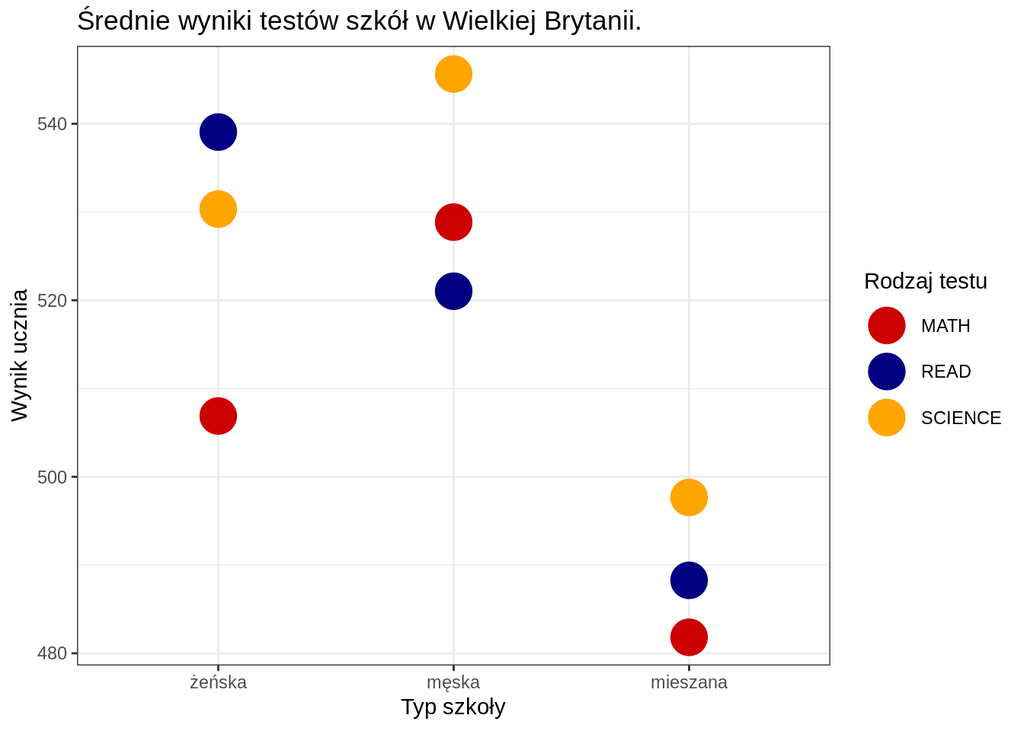

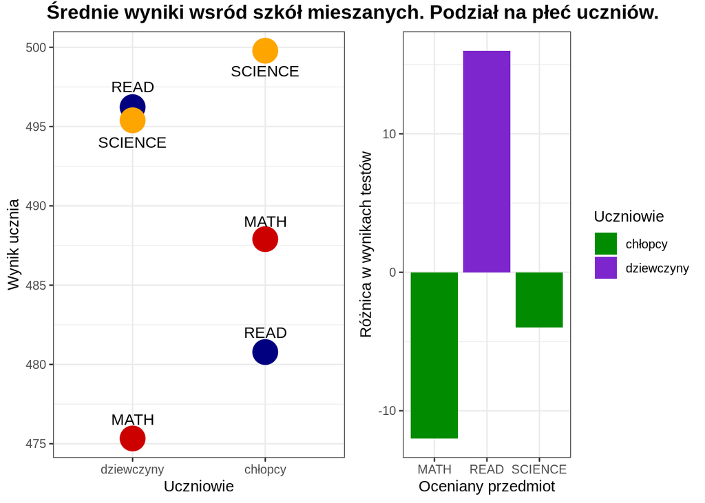

A jak wyglądają wyniki uczniów, gdy weźmiemy pod uwagę regiony w Wielkiej Brytanii? Weźmy więc średnie wyniki studentów w każdym regionie UK, podzielone na typ szkoły (męska, żeńska, mieszana).

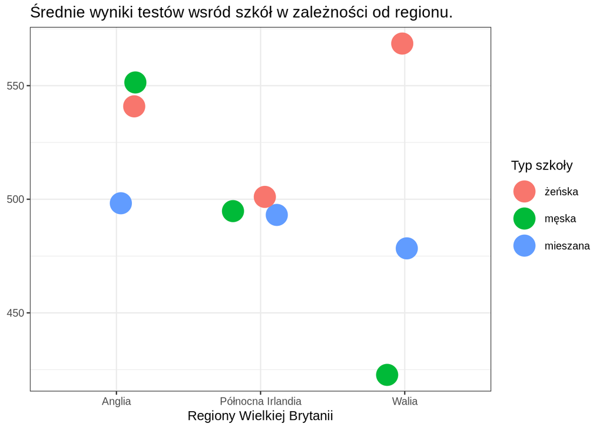

Można zauważyć, że męskie szkoły w Walii mają najgorsze wyniki, natomiast żeńśkie najlepsze. Sprawdżmy jak wygląda rozkład szkół na regiony UK.

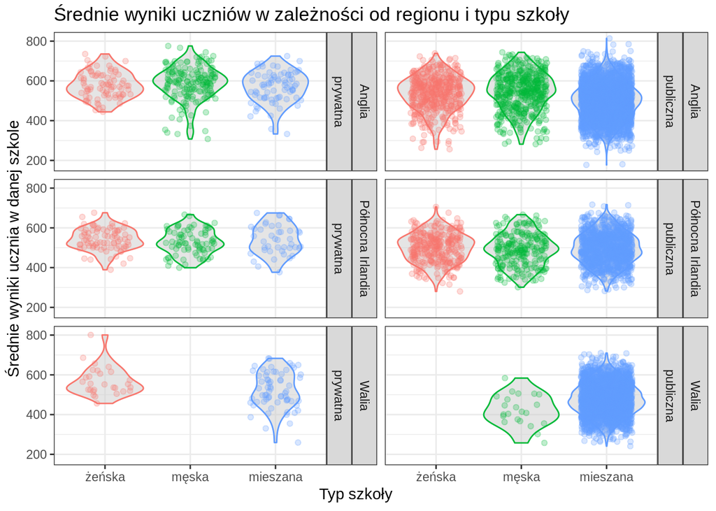

Jak zostało wspomniane na początku, w Wielkiej Brytanii państwa są podzielone też w zależności od tego skad pozyskują fundusze. Przyjrzyjmy się czy ma to wpływ na wyniki uczniów. Na wszelkich forach wspomina się, że akademie wspierane bezpośrednio przez państwo ma najlepsze wyniki, dlatego sprawdźmy czy tak jest.

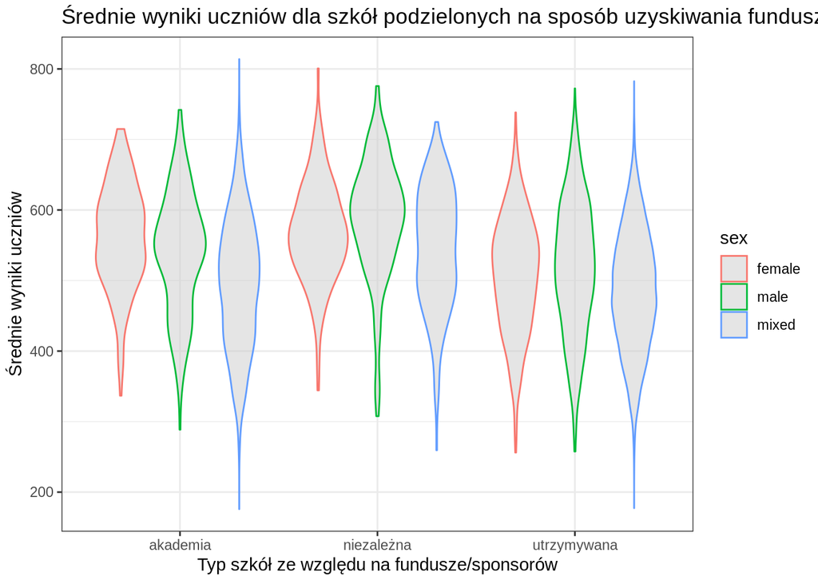

## Szkolnictwo w Wielkiej Brytanii

Sprawdźmy teraz jak wygląda rozkład szkół w zależności od wielkości miasta, a także dzieląc to na szkoły prywatne i publiczne.

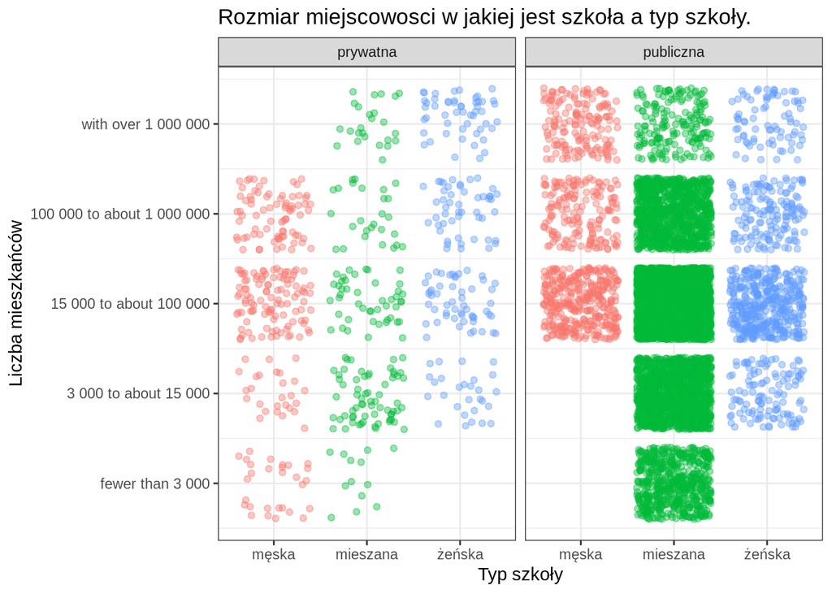

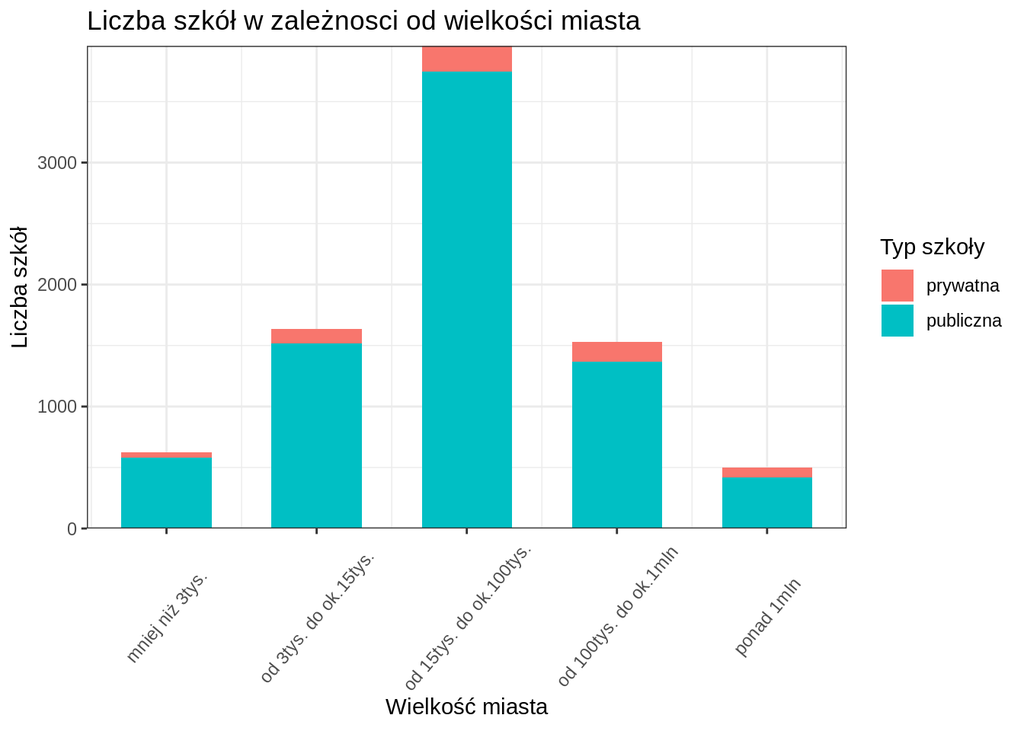

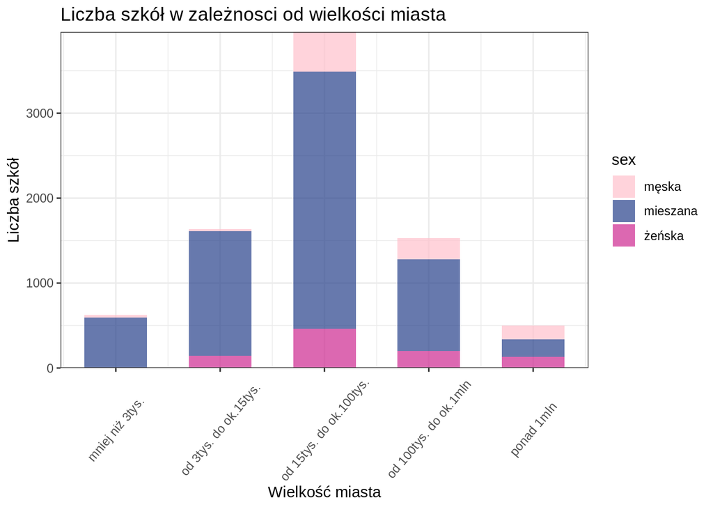

## Rodzice uczniów w szkołach UK

Sprawdżmy najpierw czy zainteresowanie i wsparcie rodziców ma odzwierdziedlenie w wynikach w nauce dziecka.

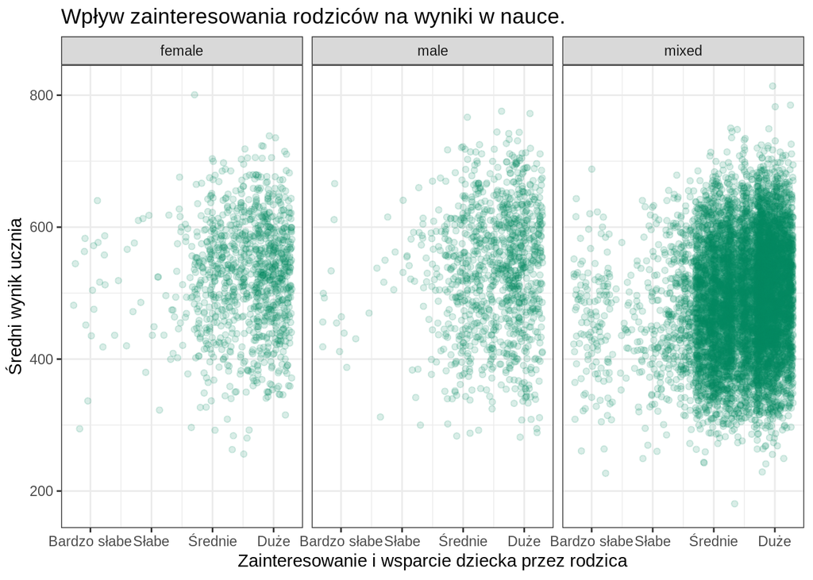

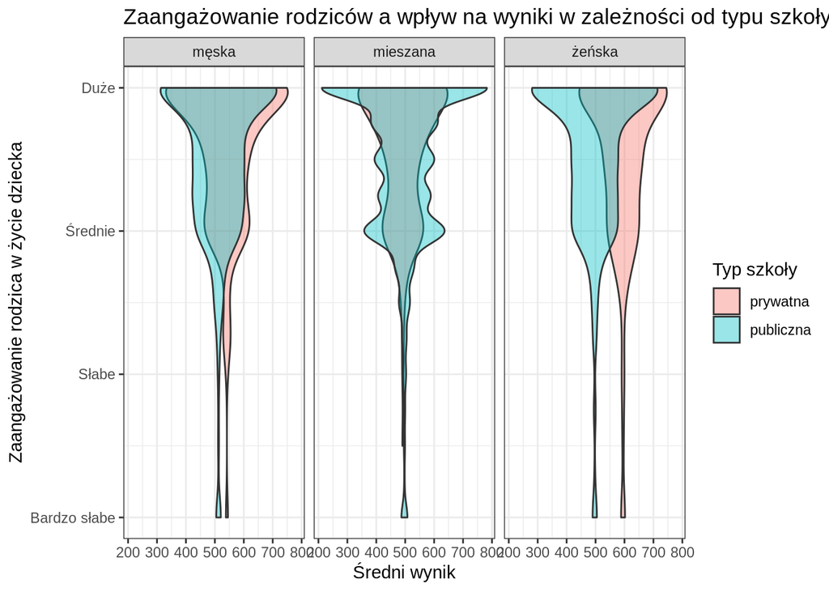

Jak widać rodzice ogólnie wspierają swoje dzieci i nie można stwierdzić, że ma to bezpośredni wpływ na ich wyniki.